# STAT 240 Discussion 6

```r
knitr::opts_chunk$set(echo = TRUE, message=FALSE, warning=FALSE)
library(tidyverse)
library(lubridate)
source("ggprob.R")
```

## Questions

### Data

The following code reads in the Madison weather data and calculates the average July temperature for each year. Treat the years from 1869 to 1898 as *early Madison* and from 1991 to 2020 as *recent Madison*.

```r
## Read and transform the Madison weather data
mw = read_csv("madison-weather-2020-clean-2.csv")

mw_july = mw %>%
  filter(month=="Jul") %>%
  filter(year < 1899 | year > 1990) %>%
  group_by(year) %>%
  summarize(tavg = mean(tavg)) %>%
  mutate(era = case_when(
    year < 1900 ~ "early",
    year > 1989 ~ "recent"))
```

### 1

Calculate the mean and standard deviation of the average July temperature separately for early Madison and recent Madison.

```r
# insert code here
early_madison_stats <- mw_july %>%
  filter(era == "early") %>%
  summarize(mean_temp = mean(tavg),
            sd_temp = sd(tavg))

recent_madison_stats <- mw_july %>%
  filter(era == "recent") %>%
  summarize(mean_temp = mean(tavg),
            sd_temp = sd(tavg))

early_madison_stats
```

```
## # A tibble: 1 × 2
##   mean_temp sd_temp
##       <dbl>   <dbl>
## 1      72.7    2.29
```

```r
recent_madison_stats
```

```
## # A tibble: 1 × 2
##   mean_temp sd_temp
##       <dbl>   <dbl>
## 1      72.0    2.94
```

### 2

Make a plot with separate density curves for the early and recent July average temperatures.

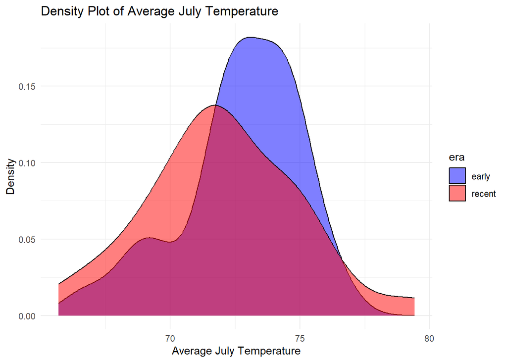

```r
# insert code here

ggplot(mw_july, aes(x = tavg, fill = era)) +
  geom_density(alpha = 0.5) +
  labs(x = "Average July Temperature", y = "Density", title = "Density Plot of Average July Temperature") +
  scale_fill_manual(values = c("early" = "blue", "recent" = "red")) +
  theme_minimal()
```